# Harry Potter Episode 7 - Dobby’s food - Confidence Intervals

## Loading packages

```r
library(data.table) # for the fread function
library(arsenal) # for creating descriptive summary statistics tables
library(tidyverse) # for ggplot2 and dplyr
```

## Load dataset

```r
dobby = fread("dobbys_food.txt")

head(dobby)
```

| food_type | weight_of_food_in_kg |
| --- | --- |
| Cake | 2.5590 |
| Pizza | 3.2875 |
| Ramen noodles | 3.4590 |
| Cake | 3.1690 |
| Pizza | 3.6475 |
| Ramen noodles | 3.6475 |

##### Explanation of dataset

- `food_type` - Types of food Dobby levitated in the past
- `weight_of_food_in_kg` - Weight of each food

## Generate a summary of the data frame using tableby from the arsenal package

```r
table_one <- tableby(food_type ~., data=dobby)

summary(table_one, title = "Dobby's food")
```

Dobby’s food

|  | Cake (N=82) | Pizza (N=94) | Ramen noodles (N=25) | Total (N=201) | p value |
| --- | --- | --- | --- | --- | --- |
| **weight_of_food_in_kg** |  |  |  |  | 0.109 |
| Mean (SD) | 6.013 (3.915) | 7.230 (4.262) | 6.186 (2.560) | 6.604 (3.974) |  |
| Range | 2.559 - 22.700 | 2.749 - 20.657 | 3.459 - 14.124 | 2.559 - 22.700 |  |

## Using tapply to calculate mean and standard deviation of the weight variable

```r
tapply(dobby$weight_of_food_in_kg, dobby$food_type, mean)
```

```
##          Cake         Pizza Ramen noodles
##      6.012909      7.229878      6.185980
```

```r
tapply(dobby$weight_of_food_in_kg, dobby$food_type, sd)
```

```
##          Cake         Pizza Ramen noodles
##      3.915164      4.261605      2.560474
```

## Generating box plot in ggplot2

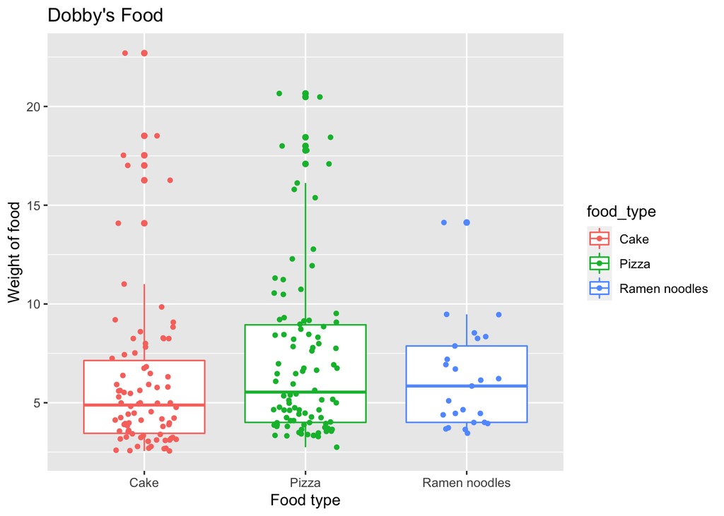

```r
p <- ggplot(dobby, aes(x=food_type, y=weight_of_food_in_kg, color=food_type)) +
  geom_boxplot() +
  geom_jitter(shape=16, position=position_jitter(0.2)) + # Box plot with jittered points, 0.2 : degree of jitter in x direction
  xlab("Food type") + ylab("Weight of food") + ggtitle("Dobby's Food")

p
```

## Calculate a confidence interval of 99% confidence level for weight

Calculating a confidence interval from a t Distribution.  
Calculating the confidence interval when using a t-test by using the command associated with the t-distribution (qt).

```r
# calculate mean and standard deviation in new columns using tidyverse dplyr

sample_size <- dobby %>% group_by(food_type) %>% tally() # count the sample size

dobby <- merge(dobby, sample_size, by="food_type")


dobby <- dobby %>% group_by(food_type)  %>%
        mutate(mean = mean(weight_of_food_in_kg)) %>% # calculate mean
        mutate(sd = sd(weight_of_food_in_kg)) # calculate standard deviation


# calculate lower bound of the 99% confidence interval for weight
dobby$lower_99 <- dobby$mean - qt(0.995, (dobby$n-1)) * dobby$sd/sqrt(dobby$n)

# calculate upper bound of the 99% confidence interval for weight
dobby$upper_99 <- dobby$mean + qt(0.995, (dobby$n-1)) * dobby$sd/sqrt(dobby$n)

# summary of results
dobby_uniq <- dobby %>% group_by(food_type) %>% slice(1L)

dobby_uniq <- dobby_uniq[,-c(2)]
head(dobby_uniq)
```

| food_type | n | mean | sd | lower_99 | upper_99 |
| --- | --- | --- | --- | --- | --- |
| Cake | 82 | 6.012909 | 3.915164 | 4.872394 | 7.153423 |
| Pizza | 94 | 7.229878 | 4.261605 | 6.073976 | 8.385779 |
| Ramen noodles | 25 | 6.185980 | 2.560474 | 4.753682 | 7.618278 |

The 99% confidence interval for weight is computed by the formula `mean ± qt(0.995,n-1) * sd/√sample size`.

Only 0.5% of the t-distribution on (n − 1) degrees of freedom resides above the percentile “qt(0.995,n-1)”. Using this percentile leaves out a total of 1% in both tails and keeps 99% of the distribution inside the central interval.

The function “qt” computes the percentiles of the t-distribution.

- The first argument to the function is a probability and the second argument is the number of degrees of freedom.
- The output of the function is the percentile associated with the probability of the first argument.
- For example, let “n” be the sample size. The output of the expression “qt(0.995,n-1)” is the 0.995-percentile of the t-distribution on (n − 1) degrees of freedom. (Source: Introduction to Statistical Thinking by Benjamin Yakir).